# Fundamentals of Missing Data

CSTAT webinar series on Responsible and Ethical Conduct of Research, East Lansing, MI

Steven J. Pierce

pierces1@msu.edu

[Center for Statistical Training and Consulting](https://cstat.msu.edu)

2026-11-05

## Outline

- What is missing data?
- Why do we end up with missing data?
- Why should we care about missing data?
- How should we start addressing missing data issues?
- How can we diagnose the missing data issues?
- How should we solve missing data issues?

# What is missing data?

Missing data (MD) are measurements you want or intended to collect but did not get<sup>[1]</sup>

- Having MD is *common* in research studies
- If you do much research, you *will* run into MD

# Why do we end up with missing data?

Data collection doesn’t always go according to plan…

Table 1: Factors That May Lead to Missing Data

| Human Factors | Other Factors |
| --- | --- |
| Participant behavior | Equipment failures |
| Researcher errors | Records/Databases |
| Partner behavior | Unusual events |

# Missing Data & Project Lifecycle

[figure not shown]

# Why should we care about missing data?

## Ethical Guidelines

Handling missing data well is an ethics issue. An ethical statistical practitioner:<sup>[2]</sup>

[figure not shown]

- “Uses methodology and data that are valid, relevant, and appropriate, without favoritism or prejudice, and in a manner intended to produce valid, interpretable, and reproducible results.”
- “Communicates data sources and fitness for use, including data generation and collection processes and known biases.”
- “Communicates data processing and transformation procedures, including missing data handling.”

## Research Ethics

The ethical quality of an analysis depends on the credibility of its assumptions<sup>[3]</sup>

- Analyses with missing data must make assumptions, some of which cannot be empirically tested
- Rigor demands using methods that can plausibly yield valid, unbiased estimates
- Poor assumptions lead to bias & misleading conclusions
- Transparency requires reporting extent of missing data, assumptions, rationales, & how we adapted the analyses

## Scientific Activities

There are 3 major scientific activities that can be affected by missing data<sup>[4]</sup>

- Making structured observations of constructs
- Using observations to draw inferences about relationships between constructs
- Generalizing results to populations beyond the collected sample

## Measurement Consequences<sup>[4]</sup>

- Availability of constructs
- Decreased reliability due to increased error variance
- Bias from poor content coverage
- Construct validity

## Internal Validity Consequences<sup>[1,4]</sup>

- Selection bias
- Compromised randomization
- Power and precision
- Inaccurate model assumptions

## Generalizability Consequences<sup>[1,4]</sup>

A representative sample is crucial to generalizing to the intended population!

- Theory development & cumulative knowledge
- Policy & decision-making

# Audience Questions (1)

Do you have questions about what missing data is and why it is important?

# How should we start addressing missing data issues?

## TARMOS Framework<sup>[5]</sup>

**T**reatment **A**nd **R**eporting of **M**issing data in **O**bservational **S**tudies

- Advocates for systematic, transparent methodology
- Recommends a 3-step approach
- Principles are applicable beyond observational studies

## TARMOS Step 1: Plan the Analysis

- Identify the analyses you would use if there were no missing data
  - Write a statistical analysis plan<sup>[6]</sup>
- Decide how you will handle missing data
  - Is a complete records analysis likely to be valid?
  - Is multiple imputation likely to offer benefits over a complete records analysis?
  - Is a sensitivity analysis required, and if so how should it be framed?

## TARMOS Step 2: Conduct the Analysis

- Examine whether data are suitable for planned analysis
  - Apply initial data analysis guidelines<sup>[7–10]</sup>
  - Diagnose missing data issues<sup>[3,4,11]</sup> *before* deciding how to handle them
  - Update the statistical analysis plan
- Conduct substantive analysis, acknowledge & justify deviations from the plan

## TARMOS Step 3: Report the Analysis

- Describe the missing data
- Describe how missing data were handled & justify the approach
- Report & interpret results

# How can we diagnose the missing data issues?

## Cattell’s Data Box<sup>[12]</sup>

[interactive chart not shown]

*How much data is there? Data volume is* $N_{values} = P \times V \times T$

- Slices through the cube represent subsets of data
- Constructs are often measured by groups of adjacent variables (items)
- Missing data puts holes in your cube!

## Slicing & Rearranging the Data Cube

[figure not shown]

## Data Structure: Long

Table 2: Long Univariate Format

| ID | Time | X1 | X2 | X3 |
| --- | --- | --- | --- | --- |
| 1 | 1 | 20 | 7 | a |
| 1 | 2 | 22 | 6 | b |
| 2 | 1 | 31 | 1 | c |
| 2 | 2 | 15 | 6 | a |
| 3 | 1 | 24 | 2 | b |
| 3 | 2 | 16 | 4 | c |

Cube: $P = 3, V = 3, T = 2$, $N_{cases} = P \times T = 6$

- Including ID & Time: $V = 5$, $N_{values} = P \times V \times T = 30$
- Excluding ID & Time: $V = 3$, $N_{values} = P \times V \times T = 18$

## Data Structure: Wide

Table 3: Wide Multivariate Format

| ID | Time 1 T1_X1 | Time 1 T1_X2 | Time 1 T1_X3 | Time 2 T2_X1 | Time 2 T2_X2 | Time 2 T2_X3 |
| --- | --- | --- | --- | --- | --- | --- |
| 1 | 20 | 7 | a | 22 | 6 | b |
| 2 | 31 | 1 | c | 15 | 6 | a |
| 3 | 24 | 2 | b | 16 | 4 | c |

Cube: $P = 3, V = 3 , T = 2$. $N_{cases} = P = 3$

- Including ID: $V = 7$, $N_{values} = P \times V = 21$
- Excluding ID: $V = 6$, $N_{values} = P \times V = 18$

## Choosing Data Structure

- Long & wide data sets are useful for different diagnostic tasks
- Pay attention to which structure you are using
- You may need *both* long & wide data sets
- Use the *relevant subset* of cases & variables in diagnostics

## Types of Missingness<sup>[4,13]</sup>

- Item level
- Construct level
- Person level (unit non-response)
- Person-period level (wave nonresponse; intermittent vs. dropout)

## Example Data: Size & Missingness Overview

Table 4: Missingness Overview for Dutch Boys Growth Study Data<sup>[14]</sup>

| Subset | Cases n | Cases % | Variables n | Variables % | Values n | Values % |
| --- | --- | --- | --- | --- | --- | --- |
| Complete | 223 | 29.8 | 1 | 11.1 | 5110 | 75.9 |
| Incomplete | 525 | 70.2 | 8 | 88.9 | 1622 | 24.1 |
| All | 748 | 100.0 | 9 | 100.0 | 6732 | 100.0 |

Note: Cross-sectional data (wide multivariate format).

## Comparing MD Overviews for Long vs Wide Data

Table 5: Meaning of Incomplete Cases and Variables By Data Set Format

| Format | Incomplete Cases | Incomplete Variables |
| --- | --- | --- |
| Wide | Persons with any MD (across variables & times) | Variables with any MD at specific times (across persons) |
| Long | Persons with any MD at specific times (across variables) | Variables with any MD (across persons & times) |

## Example Data: Variable-Level Missingness

Table 6: Item/Construct Missingness for Dutch Boys Growth Study Data<sup>[14]</sup>

| Variable | Observed n | Observed % | Missing n | Missing % |
| --- | --- | --- | --- | --- |
| age | 748 | 100.0 | 0 | 0.0 |
| hgt | 728 | 97.3 | 20 | 2.7 |
| wgt | 744 | 99.5 | 4 | 0.5 |
| bmi | 727 | 97.2 | 21 | 2.8 |
| hc | 702 | 93.9 | 46 | 6.1 |
| gen | 245 | 32.8 | 503 | 67.2 |
| phb | 245 | 32.8 | 503 | 67.2 |
| tv | 226 | 30.2 | 522 | 69.8 |
| reg | 745 | 99.6 | 3 | 0.4 |

Note: Cross-sectional data (wide multivariate format).

- Age is a 1-item construct
- Body mass index is a **2-item construct**:
  - $bmi = wgt/hgt^2$
  - Both *items* are required

## Describing the Amount of MD<sup>[4,15]</sup>

Report numbers & percentages of:

- Incomplete cases, variables, & values (overall & by time)
- Missing values per variable/construct (overall & by time)
- Participants w/ *any observed data* at each time point (retention/attendance)
- Reasons for dropout and other types of missing data

## Tracking Systems

Use a tracking system to organize & document data collection

- Whether & when participants attend each data collection event
- When, how, & why participants exit the study

## CONSORT 2025 Statement<sup>[16]</sup>

- Requires disclosing how you handled MD
- Flow charting sample size by stage of study:
  - Uses tracking data
  - Reveals dropout

[figure not shown]

## Patterns of Missing Data<sup>[13]</sup>

- **Y**: matrix of all the values that *could* be observed
- **Y_obs**: subset of *observed* **Y** values
- **Y_miss**: subset of *missing* **Y** values
- **R**: response matrix of dummy-coded missingness indicators showing which **Y** values are observed (0, part of **Y_obs**) vs. missing (1, part of **Y_miss**)

**Tip**

We can aggregrate and visualize **R** to describe patterns of missingness!

## Example Data: MD Patterns Plot

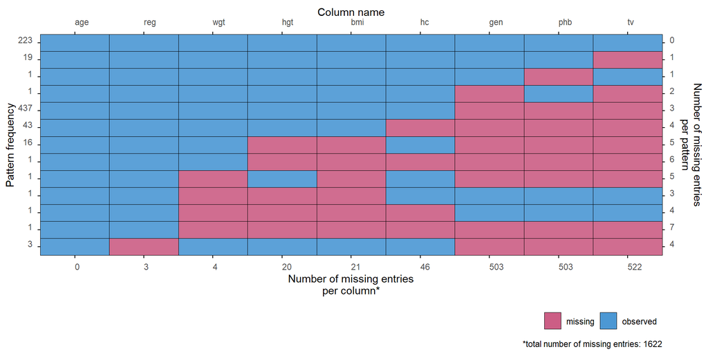

Missingness patterns for Dutch boys growth study data (748 boys, 9 variables, 1 time point)<sup>[14]</sup>

## Using MD Pattern Plots

Look for patterns that:

- Are common (i.e., high frequency)
- Have large numbers of missing values
- Relate item missingness to construct missingness
- Show entire data collection events being skipped
- Show intermittent attendance or dropout

## Rubin’s Mechanisms of Missingness<sup>[17]</sup>

- Missing completely at random (MCAR)
- Missing at random (MAR)
- Missing not at random (MNAR)

**Impact on Statistical Results<sup>[4]</sup>**

Some mechanisms yield more bias: **MCAR < MAR < MNAR**

## MCAR

MCAR is when neither observed nor unobserved values predict which values are missing

[figure not shown]

## MAR

MAR is when observed values predict which values are missing

[figure not shown]

## MNAR

MNAR is when unobserved values predict which values are missing

[figure not shown]

## Rubin’s Mechanisms & Cattell’s Box<sup>[4,12,17]</sup>

Classifying large datasets according to Rubin’s mechanisms is *messy*

- Subsets of the data may fit into different mechanisms
- Classify mechanisms for meaningful subsets of data defined by dimensions of the data box (persons, variables, times)<sup>[4]</sup>
- Consider structured approaches to diagnosing mechanisms<sup>[18,19]</sup>

## Predictors of Missingness in Longitudinal Studies

- Study arms and/or sites
- Baseline/pretest values of outcome variables
- Other covariates (demographics)

**Tip**

Consider predictors of person, item, construct, and person-period missingness. Think carefully about your study context and data to look for meaningful, sensible things to test when evaluating missing data issues.

# Audience Questions (2)

Do you have questions about diagnosing missing data issues?

# How should we solve missing data issues?

## Prevention<sup>[4,20,21]</sup>

“An ounce of prevention is worth a pound of cure.” (Benjamin Franklin, 1735)

- The amount of missing data affects its potential impact on the study
- Design your study to reduce the amount of missing data

## Prevention: Data Collection Frequency & Timing<sup>[4]</sup>

- Frequent data collection with short intervals between events is burdensome
- Collect longitudinal data at sensible times given expected temporal patterns

## Prevention: Number of Variables<sup>[4,20,21]</sup>

Every variable is an opportunity for missing data

- Only collect variables that you need
- Choose instruments wisely (short, reliable, valid, & relevant)
- Consider collecting multiple measures of key constructs

## Prevention: Dropout<sup>[4,20–22]</sup>

- Establish relationships
- Maintain contact with participants
- Offer adequate incentives
- Make participation convenient

## Prevention: Data Collection Methods

- Develop detailed protocols
- Train data collection & entry staff
- Pay attention to instrument design
- Test equipment & instruments

## Treatment: Traditional Methods<sup>[4,11]</sup>

Table 7

| Data Deletion | Single Imputation |
| --- | --- |
| Listwise deletion | Mean Substitution |
| Pairwise deletion | Hot-Deck Imputation |
| Available Items Analysis | Last Observation Carried Forward |
|  | Regression Imputation |

## Treatment: Modern Methods<sup>[4,11]</sup>

- Full-information maximum likelihood (FIML) estimation
- Multiple imputation (MI)

## FIML (1)<sup>[4,11]</sup>

FIML estimates parameters by combining observed data, relationships among observed variables, & distribution assumptions

- Seeks parameter estimates that best fit the data
- Uses all available data without imputing any values
- Benefits from auxilliary variables

## FIML (2)<sup>[4,11]</sup>

- Works well with MCAR & MAR data
- Yields biased estimates under MNAR

**Tip**

FIML is usually available in structural equation modeling (SEM) software.

## MI (1)<sup>[4,11,15]</sup>

[figure not shown]

## MI (2)<sup>[4,11,15]</sup>

- Benefits from auxilliary variables
- Imputation model must contain analysis model
- Preserves uncertainty & quantifies influence of MD
- Works well with MCAR & MAR data
- Can *sometimes* handle MNAR data

## Where to Learn More

- Short overviews<sup>[1,13,23–26]</sup>
- Some good textbooks<sup>[4,11,15,27]</sup>
- Dealing with item-level missingness in scale scores<sup>[24,26]</sup>
- Advanced diagnostics<sup>[18,19,28]</sup>
- Preventing missing data in:
  - Clinical studies<sup>[21]</sup>
  - Longitudinal studies<sup>[22]</sup>
  - Surveys<sup>[20]</sup>

## Software Tools

- SPSS: check out the `MVA` and `MULTIPLE IMPUTATION` syntax commands
- R packages: see the [CRAN Task View on Missing Data](https://cran.r-project.org/view=MissingData)
- Both FIML and MI are supported by Mplus and the R package lavaan

## References

1. Fernández-García, M. P., Vallejo-Seco, G., Livácic-Rojas, P., & Tuero-Herrero, E. (2018). The (ir)responsibility of (under)estimating missing data. *Frontiers in Psychology*, *9*(556). https://doi.org/10.3389/fpsyg.2018.00556

2. American Statistical Association Committee on Professional Ethics. (2022). *Ethical guidelines for statistical practice.* [Web Page]. American Statistical Association. https://www.amstat.org/your-career/ethical-guidelines-for-statistical-practice

3. Enders, C. K., & Gottschall, A. C. (2011). The impact of missing data on the ethical quality of a research study. In A. T. Panter & S. K. Sterba (Eds.), *Handbook of ethics in quantitative methodology* (pp. 357–381). Routledge/Taylor & Francis Group.

4. McKnight, P. E., McKnight, K. M., Sidani, S., & Figueredo, A. J. (2007). *Missing data: A gentle introduction*. Guilford Press.

5. Lee, K. J., Tilling, K. M., Cornish, R. P., Little, R. J. A., Bell, M. L., Goetghebeur, E., Hogan, J. W., Carpenter, J. R., & STRATOS Initiative, on behalf of the. (2021). Framework for the treatment and reporting of missing data in observational studies: The treatment and reporting of missing data in observational studies framework. *Journal of Clinical Epidemiology*, *134*, 79–88. https://doi.org/10.1016/j.jclinepi.2021.01.008

6. Cressman, K., & Sharp, J. L. (2022). Crafting statistical analysis plans: A cross-discipline approach. *Stat*, *11*(1). https://doi.org/10.1002/sta4.528

7. Baillie, M., Cessie, S. le, Schmidt, C. O., Lusa, L., Huebner, M., & Topic Group "Initial Data Analysis" of the STRATOS Initiative, for the. (2022). Ten simple rules for initial data analysis. *PLoS Computational Biology*, *18*(2), e1009819. https://doi.org/10.1371/journal.pcbi.1009819

8. Heinze, G., Baillie, M., Lusa, L., Sauerbrei, W., Schmidt, C. O., Harrell Jr., F. E., Huebner, M., TG2, on behalf of the, & STRATOS initiative, T. of the. (2024). Regression without regrets – initial data analysis is a prerequisite for multivariable regression. *BMC Medical Research Methodology*, *24*. https://doi.org/10.1186/s12874-024-02294-3

9. Huebner, M., Cessie, S. le, Schmidt, C., & Vach, W. (2018). A contemporary conceptual framework for initial data analysis. *Observational Studies*, *4*(1), 171–192. https://doi.org/10.1353/obs.2018.0014

10. Huebner, M., Vach, W., Le Cessie, S., Schmidt, C. O., Lusa, L., & Topic Group “Initial Data Analysis” of the STRATOS Initiative, on behalf of the. (2020). Hidden analyses: A review of reporting practice and recommendations for more transparent reporting of initial data analyses. *BMC Medical Research Methodology*, *20*(61), 1–10. https://doi.org/10.1186/s12874-020-00942-y

11. Enders, C. K. (2022). *Applied missing data analysis* (2nd ed.). Guilford Press. https://www.appliedmissingdata.com

12. Cattell, R. B. (1966). The data box: Its ordering of total resources in terms of possible relations systems. In R. B. Cattell (Ed.), *Handbook of multivariate experimental psychology* (pp. 67–128). Rand McNally.

13. Schafer, J. L., & Graham, J. W. (2002). Missing data: Our view of the state of the art. *Psychological Bulletin*, *7*(2), 147–777. https://doi.org/10.1037//1082-989X.7.2.I47

14. Fredriks, A. M., van Buuren, S., Burgmeijer, R. J. F., Meulmeester, J. F., Beuker, R. J., Brugman, E., Roede, M. J., Verloove-Vanhorick, S. P., & Wit, J.-M. (2000). Continuing positive secular growth change in the netherlands 1955-1997. *Pediatric Research*, *47*, 316–323. https://doi.org/10.1203/00006450-200003000-00006

15. van Buuren, S. (2018). *Flexible imputation of missing data* (2nd ed.). Chapman & Hall/CRC Press. https://doi.org/10.1201/9780429492259

16. Hopewell, S., Chan, A.-W., Collins, G. S., Hróbjartsson, A., Moher, D., Schulz, K. F., Tunn, R., Aggarwal, R., Berkwits, M., Berlin, J. A., Bhandari, N., Butcher, N. J., Campbell, M. K., Chidebe, R. C. W., Elbourne, D., Farmer, A., Fergusson, D. A., Golub, R. M., Goodman, S. N., … Boutron, I. (2025). CONSORT 2025 statement: Updated guideline for reporting randomized trials. *JAMA*, *333*(22), 1998–2005. https://doi.org/10.1001/jama.2025.4347

17. Rubin, D. B. (1976). Inference and missing data. *Biometrika*, *63*(3), 581–592. https://doi.org/10.1093/biomet/63.3.581

18. Matute, J., Beule, A. G., Huebner, M., Schmidt, C. O., Völzke, H., & Linsen, L. (2026). Exploratory visual analysis of missing data for multiple imputation [Advance online publication]. *Information Visualization*. https://doi.org/10.1177/14738716261465405

19. Weberpals, J., Raman, S. R., Shaw, P. A., Lee, H., Hammil, B. G., Toh, S., Connolly, J. G., Dandreo, K. J., Tian, F., Liu, W., Li, J., Hernández‑Muñoz, J. J., Glynn, R. J., & Desai, R. J. (2024). smdi: An R package to perform structural missing data investigations on partially observed confounders in real-world evidence studies. *JAMIA Open*, *7*(1). https://doi.org/10.1093/jamiaopen/ooae008

20. Leeuw, E. D. de. (2001). Reducing missing data in surveys: An overview of methods. *Quality & Quantity*, *35*(2), 147–160. https://doi.org/10.1023/A:1010395805406

21. Wisniewski, S. R., Leon, A. C., Otto, M. W., & Trivedi, M. H. (2006). Prevention of missing data in clinical research studies. *Biological Psychiatry*, *59*, 997–1000. https://doi.org/10.1016/j.biopsych.2006.01.017

22. Laurie, H. (2008). Minimizing panel attrition. In S. Menard (Ed.), *Handbook of longitudinal research* (pp. 167–184). Academic Press.

23. El-Masri, M. M., & Fox-Wasylyshyn, S. M. (2005). Missing data: An introductory conceptual overview for the novice researcher. *Canadian Journal of Nursing Research*, *37*(4), 156–171.

24. Graham, J. W. (2009). Missing data analysis: Making it work in the real world. *Annual Review of Psychology*, *60*, 549–576. https://doi.org/10.1146/annurev.psych.58.110405.085530

25. Little, T. D., Jorgensen, T. D., Lang, K. M., & Moore, E. W. (2014). On the joys of missing data. *Journal of Pediatric Psychology*, *39*(2), 151–162. https://doi.org/10.1093/jpepsy/jst048

26. Newman, D. A. (2014). Missing data: Five practical guidelines. *Organizational Research Methods*, *17*(4), 372–411. https://doi.org/10.1177/1094428114548590

27. Graham, J. W. (2013). *Missing data: Analysis and design*. Springer. https://doi.org/10.1007/978-1-4614-4018-5

28. Tierney, N. J., Harden, F. A., Harden, M. J., & Mengerson, K. L. (2015). Using decision trees to understand structure in missing data. *BMJ Open*, *5*(6). https://doi.org/10.1136/bmjopen-2014-007450

# Discussion time!

What questions do you have about missing data issues?